# CPLN 675 Midterm Project: Flood Inundation.

Qi Si

3/20/2022

```r
# set work directory
setwd("C:/Users/fiona/Desktop/CPLN 675/midproject")
```

```r
# set up environment
library(caret)
library(pscl)
library(plotROC)
library(pROC)
library(sf)
library(tidyverse)
library(knitr)
library(kableExtra)
library(tigris)
library(viridis)
library(ggmap)  # consider removing later, if no basemap added
library(gridExtra)
```

```r
mapTheme <- theme(plot.title =element_text(size=12),
                  plot.subtitle = element_text(size=8),
                  plot.caption = element_text(size = 8),
                  axis.line=element_blank(),
                  axis.text.x=element_blank(),
                  axis.text.y=element_blank(),
                  axis.ticks=element_blank(),
                  axis.title.x=element_blank(),
                  axis.title.y=element_blank(),
                  panel.background=element_blank(),
                  panel.grid.major=element_line(colour = 'transparent'),
                  panel.grid.minor=element_blank(),
                  panel.border = element_rect(colour = "black", fill=NA, size=0.75),
                  legend.direction = "vertical",
                  legend.position = "right",
                  plot.margin = margin(0.1, 0.1, 0.1, 0.1, 'cm'),
                  legend.key.height = unit(1, "cm"), legend.key.width = unit(0.1, "cm"))

plotTheme <- theme(
  plot.title =element_text(size=12),
  plot.subtitle = element_text(size=8),
  plot.caption = element_text(size = 6),
  axis.text.x = element_text(size = 10, angle = 45, hjust = 1),
  axis.text.y = element_text(size = 10),
  axis.title.y = element_text(size = 10),
  # Set the entire chart region to blank
  panel.background=element_blank(),
  plot.background=element_blank(),
  #panel.border=element_rect(colour="#F0F0F0"),
  # Format the grid
  panel.grid.major=element_line(colour="#D0D0D0",size=.75),
  axis.ticks=element_blank())
```

# 1. Overview

Calgary is a city locates in southern Alberta, Canada, and it is the third most populous municipality in Canada. As of 2021, its population reached 1,306,784, and its land area is about 820.63 square kilometers. The city is vulnerable to floods since it has extensive development along the Elbow River and Bow River.

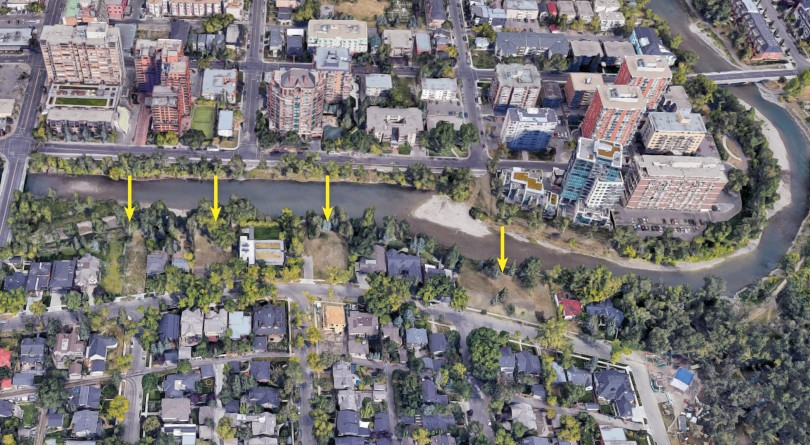

Moreover, the risk of flooding will continue to increase as climate change ongoing; the accelerated snowmelt in spring will add extraordinary pressure on the watercourse and city sewer system. As one of the largest cities in the country, Calgary has a relatively comprehensive flood monitoring approach and has collected a fair amount of data for floods. By using the given flood satellite image and the DEM, along with the landcover data our group collected, we fitted a generalized linear model to predict flood in Calgary. With the given flood inundation data, we were able to cross-validate the model we established and then applied it to Edmonton, a comparable city to Calgary, to predict inundation for the city.

# 2. Data Preparation and Visualization

Inundation is highly related to factors such as land cover, slope, blue spot that identify flood sensitive areas, and distance to water. In this analysis, we collected the DEM, city boundary, and landcover data for both Calgary and the comparable city Edmonton then generated 500*500m fishnet for both cities. Based on these datasets, we calculated the average distance to stream, percent Inundation, percent developed area, percent water coverage, average slope within each fishnet by using ArcGIS Pro. And here is a visualization of these variables for Calgary. When preparing the data, we assumed that the cell floods (Inundation_indicator == 1) when the percent of inundation (area) is greater than or equal to 25%.

```r
# Calgary data:
Calgary_dat <- st_read("./midTermProject_Data/CAL_Fish0328/CAL_Fish0328/CAL_Fishnet_Clip0328.shp") %>%
  st_transform(crs = 3780)
#Calgary_boundary <- st_read("./midTermProject_Data/CALGIS_CITYBOUND_LIMIT/CALGIS_CITYBOUND_LIMIT.shp") %>%
#  st_transform(crs = 3780)

# Edmonton data:
Edmonton_dat <- st_read("./midTermProject_Data/Edmont_Fish0328/Edmont_Fish0328/Edmonton_FIsh0328.shp") %>%
  st_transform(crs = 3780)
#Edmonton_boundary <- st_read("./midTermProject_Data/City of Edmonton - Corporate Boundary #(current)/geo_export_0c4138a9-f214-4eda-90e6-47ac315dac21.shp") %>%
#  st_transform(crs = 3780)


# adding/adjust variables
Calgary_dat_new <- Calgary_dat %>%
  mutate(Inundation_indicator = as.integer(ifelse(Pct_Inun >= 0.25,1, 0)),  # change percent of inundation to a dummy indicator.
         Dis_Stream_mile = Dis_Stream/1609.34)  # convert from meter to mile for better histogram visualization.
```

## 2.1 Visualize Variables

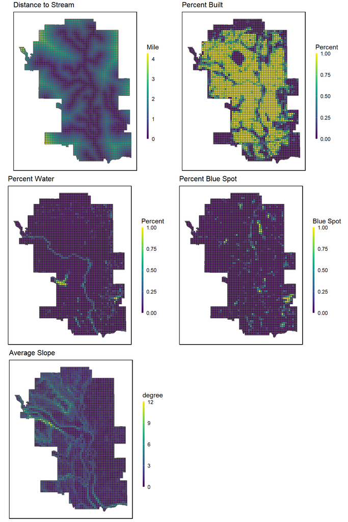

```r
Dis_stream_Plot <-
  ggplot() +
    geom_sf(data = Calgary_dat_new, aes(fill=Dis_Stream_mile)) +
    scale_fill_viridis(name="Mile") + labs(title="Distance to Stream") +
    mapTheme

Pct_Built_Plot <-
  ggplot() +
    geom_sf(data=Calgary_dat_new, aes(fill=Pct_Built)) +
    scale_fill_viridis(name="Percent") + labs(title="Percent Built") +
    mapTheme

Pct_water_Plot <-
  ggplot() +
    geom_sf(data=Calgary_dat_new, aes(fill=Pct_water)) +
    scale_fill_viridis(name="Percent") + labs(title="Percent Water") +
    mapTheme

BS_Plot <-
  ggplot() +
    geom_sf(data=Calgary_dat_new, aes(fill=Pct_BS)) +
    scale_fill_viridis(name="Blue Spot") + labs(title="Percent Blue Spot") +
    mapTheme

Ave_Slope_Plot <-
  ggplot() +
    geom_sf(data=Calgary_dat_new, aes(fill=Ave_Slope)) +
    scale_fill_viridis(name="degree") + labs(title="Average Slope") +
    mapTheme

grid.arrange(Dis_stream_Plot,Pct_Built_Plot,Pct_water_Plot,BS_Plot,
             Ave_Slope_Plot, ncol=2)
```

## 2.2 Glimpse on the Data

As the output shows, There are 3553 cells in total, 3305 of them are considered as not inundated, while 248 are considered inundated.

```r
 Calgary_dat_new %>% group_by(Inundation_indicator) %>% tally()
```

```
## Simple feature collection with 2 features and 2 fields
## Geometry type: MULTIPOLYGON
## Dimension:     XYZ
## Bounding box:  xmin: -22098.3 ymin: 5634037 xmax: 9864.369 ymax: 5675150
## z_range:       zmin: 0 zmax: 0
## Projected CRS: NAD83(CSRS) / Alberta 3TM ref merid 114 W
## # A tibble: 2 x 3
##   Inundation_indicat~     n                                             geometry
##                 <int> <int>                                   <MULTIPOLYGON [m]>
## 1                   0  3305 Z (((4412.818 5635081 0, 4409.771 5635080 0, 4407.0~
## 2                   1   248 Z (((3303.144 5634040 0, 3299.532 5634041 0, 3296.5~
```

## 2.3 Plot Inundation

Based on the given flood aerial image and our assumption of inundation, we generated a map showing the inundation area in fishnet format. As the map below shows, the blue cells represent areas inundated, and the green color shows areas that are not inundated.

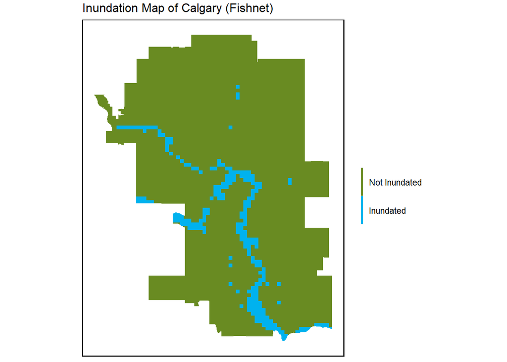

```r
ggplot() +
  geom_sf(data=Calgary_dat_new, aes(fill=as.factor(Inundation_indicator)), color = "transparent") +
  scale_fill_manual(values = c("olivedrab4", "deepskyblue2"),
                    labels = c("Not Inundated","Inundated"),
                    name = "") +
  labs(title="Inundation Map of Calgary (Fishnet)") +
  mapTheme
```

## 2.4 Histogram

Here is an overview of the histogram for each variable grouped by inundation indicator. According to the histogram, we can briefly draw the conclusion that areas with a steeper slope, closer to stream, less developed (Pct_Built), higher blue spot coverage, and closer to water bodies are more likely to flood.

```r
InundationPlotVariable <-
   Calgary_dat_new%>%
  as.data.frame() %>%
  select(Inundation_indicator,Dis_Stream_mile,Pct_Built,Pct_water,Pct_BS,Ave_Slope) %>%
  gather(variable, value, -Inundation_indicator)
```

```r
Calgary_dat_new %>% as.data.frame() %>%
   select(Inundation_indicator,Dis_Stream_mile,Pct_Built,Pct_water,Pct_BS,Ave_Slope) %>%
    pivot_longer(cols = -Inundation_indicator)
```

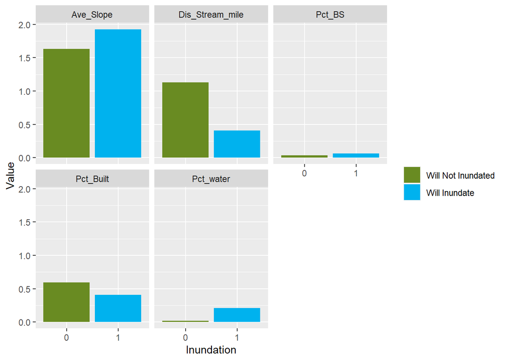

```r
ggplot(InundationPlotVariable  %>%
         group_by(Inundation_indicator, variable) %>%
         summarize(mean = mean(value))) +
     geom_bar(aes(as.factor(Inundation_indicator),
                  mean,
                  fill=as.factor(Inundation_indicator)),
              stat="identity") +
     facet_wrap(~variable) +
     scale_fill_manual(values = c("olivedrab4", "deepskyblue2"),
                      labels = c("Will Not Inundated","Will Inundate"),
                      name = "") +
    labs(x="Inundation", y="Value")
```

# 3. Modeling

## 3.1 Split Dataset

To test the validation of the model, this analysis split the fishnet dataset for Calgary into 70/30 training-test sets.

```r
set.seed (47)
sample <- sample.int(n = nrow(Calgary_dat_new), size = floor(.7*nrow(Calgary_dat_new)), replace = F)
train <- Calgary_dat_new[sample, ]
test  <- Calgary_dat_new[-sample, ]
```

## 3.2 Build Model

```r
InundationModel <- glm(Inundation_indicator ~ .,
                    family="binomial"(link="logit"), data = train %>%
                                                            as.data.frame() %>%
                                                            select(-geometry, -Shape_Leng, -Shape_Area,-Dis_Stream,-Pct_Inun, -BS_YN))
summary(InundationModel)
```

```
##
## Call:
## glm(formula = Inundation_indicator ~ ., family = binomial(link = "logit"),
##     data = train %>% as.data.frame() %>% select(-geometry, -Shape_Leng,
##         -Shape_Area, -Dis_Stream, -Pct_Inun, -BS_YN))
##
## Deviance Residuals:
##     Min       1Q   Median       3Q      Max
## -2.7928  -0.3345  -0.2097  -0.1088   3.4932
##
## Coefficients:
##                 Estimate Std. Error z value Pr(>|z|)
## (Intercept)     -1.46188    0.23040  -6.345 2.22e-10 ***
## Pct_Built       -0.95773    0.25435  -3.765 0.000166 ***
## Pct_water        8.70483    0.73874  11.783  < 2e-16 ***
## Ave_Slope        0.10985    0.05035   2.182 0.029126 *
## Pct_BS          -2.96822    0.83693  -3.547 0.000390 ***
## Dis_Stream_mile -1.76010    0.18275  -9.631  < 2e-16 ***
## ---
## Signif. codes:  0 '***' 0.001 '**' 0.01 '*' 0.05 '.' 0.1 ' ' 1
##
## (Dispersion parameter for binomial family taken to be 1)
##
##     Null deviance: 1302.14  on 2486  degrees of freedom
## Residual deviance:  867.82  on 2481  degrees of freedom
## AIC: 879.82
##
## Number of Fisher Scoring iterations: 7
```

## 3.3 Model validation

### 3.3.1 Visualize Statistics

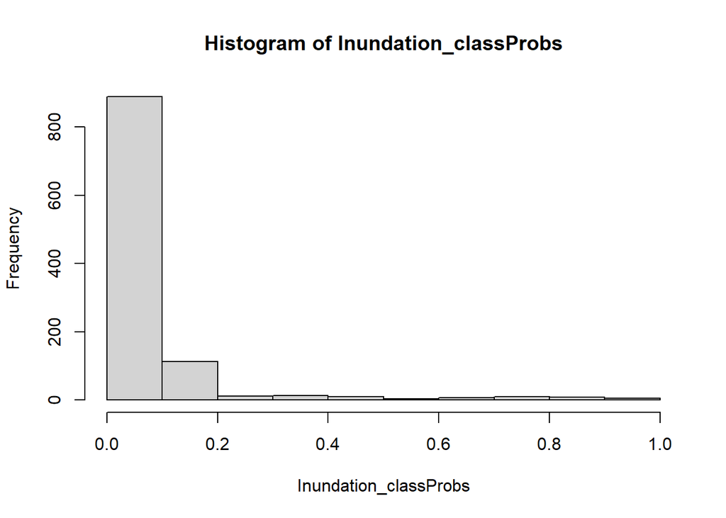

```r
Inundation_classProbs <- predict(InundationModel, test, type="response")

hist(Inundation_classProbs)
```

The chart below shows the predicted inundation probability for an area labeled as inundate or not inundate based on the given flood satellite image and our assumption that when the flood area exceeds or is equal to 25% of the total cell area will be considered as inundating. As the plot below shows, most of the cells labeled as not inundate tend to have a very low probability of flood based on our model, and areas labeled as “inundate” tend to have a more diversified probability of inundation based on the established model.

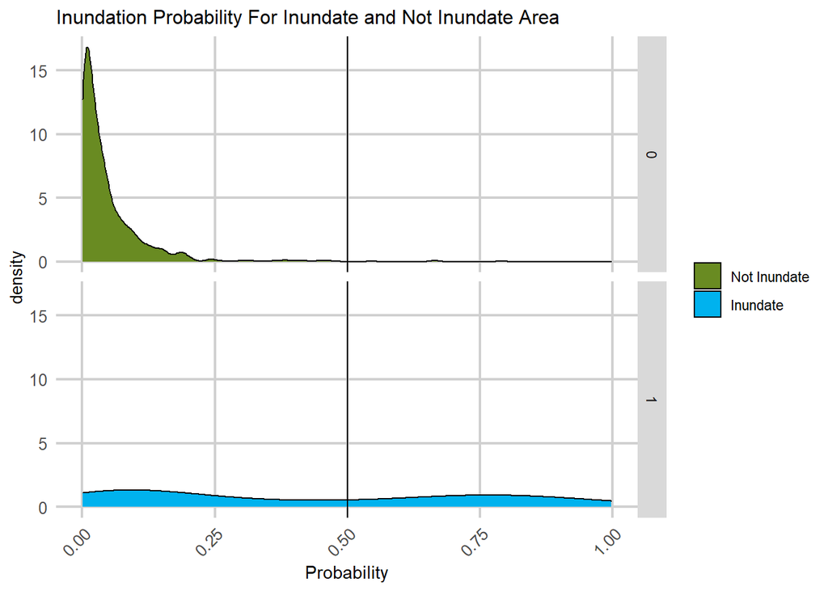

```r
Inundation_testProbs <- data.frame(obs = as.numeric(test$Inundation_indicator),
                        pred = Inundation_classProbs)

ggplot(Inundation_testProbs, aes(x = pred, fill=as.factor(obs))) +
  geom_density() +
  facet_grid(obs ~ .) +
  xlab("Probability") +
  geom_vline(xintercept = .5) +
  scale_fill_manual(values = c("olivedrab4", "deepskyblue2"),
                      labels = c("Not Inundate","Inundate"),
                      name = "")+
  plotTheme+
  labs(title="Inundation Probability For Inundate and Not Inundate Area")
```

### 3.3.2 Confusion Metrics and ROC

To calculate the confusion metrics, we assumed that the cell will be considered as Inundated when the predicted inundation rate is greater than or equal to 0.25, in accordance with our assumption of identifying inundate cells in the beginning of this analysis.As the result show, when the threshold were set at 0.25, the accuracy of the model is around 0.9512, and the Area Under the Curve (ROC) is about 0.8805.

```r
Inundation_testProbs$predClass  = ifelse(Inundation_testProbs$pred >= .25 ,1,0)

caret::confusionMatrix(reference = as.factor(Inundation_testProbs$obs),
                       data = as.factor(Inundation_testProbs$predClass),
                       positive = "1")
```

```
## Confusion Matrix and Statistics
##
##           Reference
## Prediction   0   1
##          0 978  30
##          1  22  36
##
##                Accuracy : 0.9512
##                  95% CI : (0.9365, 0.9634)
##     No Information Rate : 0.9381
##     P-Value [Acc > NIR] : 0.03952
##
##                   Kappa : 0.5549
##
##  Mcnemar's Test P-Value : 0.33169
##
##             Sensitivity : 0.54545
##             Specificity : 0.97800
##          Pos Pred Value : 0.62069
##          Neg Pred Value : 0.97024
##              Prevalence : 0.06191
##          Detection Rate : 0.03377
##    Detection Prevalence : 0.05441
##       Balanced Accuracy : 0.76173
##
##        'Positive' Class : 1
##
```

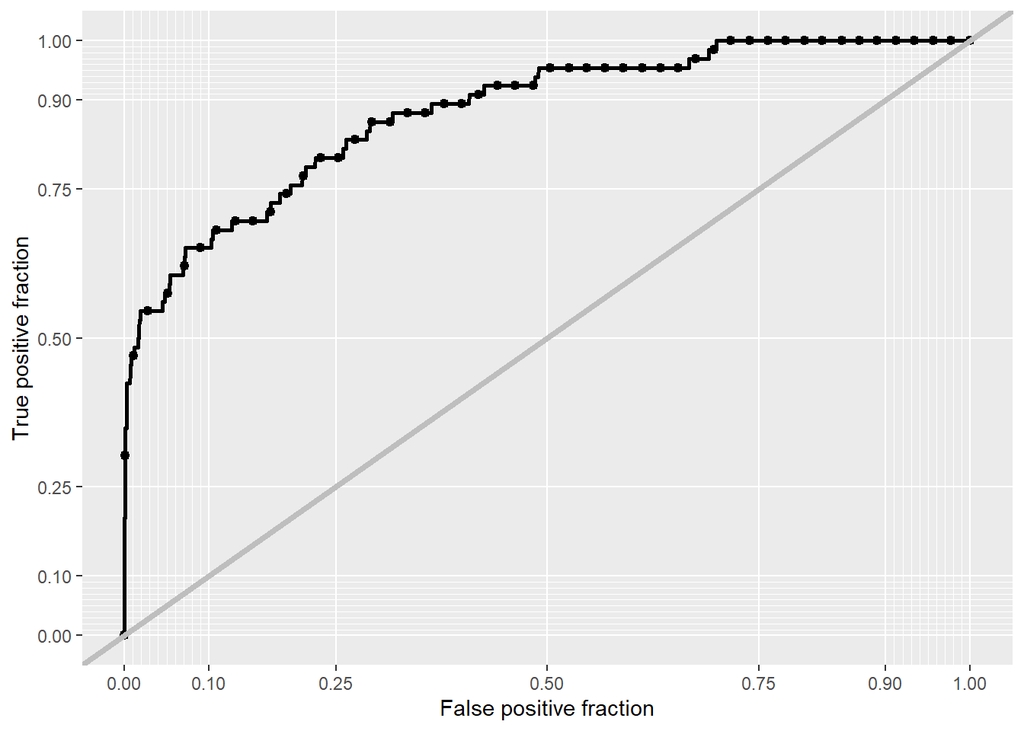

```r
ggplot(Inundation_testProbs, aes(d = obs, m = pred)) +
  geom_roc(n.cuts = 50, labels = FALSE) +
  style_roc(theme = theme_grey) +
  geom_abline(slope = 1, intercept = 0, size = 1.5, color = 'grey')
```

```r
auc(Inundation_testProbs$obs, Inundation_testProbs$pred)
```

```
## Area under the curve: 0.8805
```

### 3.3.3 Cross Validation

```r
Inundation_ctrl <- trainControl(method = "cv",
                     number = 100,
                     savePredictions = TRUE)

Inundation_cvFit <- train(as.factor(Inundation_indicator) ~ .,  data = Calgary_dat_new %>%
                                                as.data.frame() %>%
                                                select(-geometry,-Dis_Stream,-Pct_Inun, -Shape_Area,-Shape_Leng, -BS_YN),
               method="glm", family="binomial",
               trControl = Inundation_ctrl)

Inundation_cvFit
```

```
## Generalized Linear Model
##
## 3553 samples
##    5 predictor
##    2 classes: '0', '1'
##
## No pre-processing
## Resampling: Cross-Validated (100 fold)
## Summary of sample sizes: 3517, 3517, 3518, 3518, 3518, 3518, ...
## Resampling results:
##
##   Accuracy   Kappa
##   0.9480768  0.413497
```

Here is a histogram of accuracy across all 100 folds.

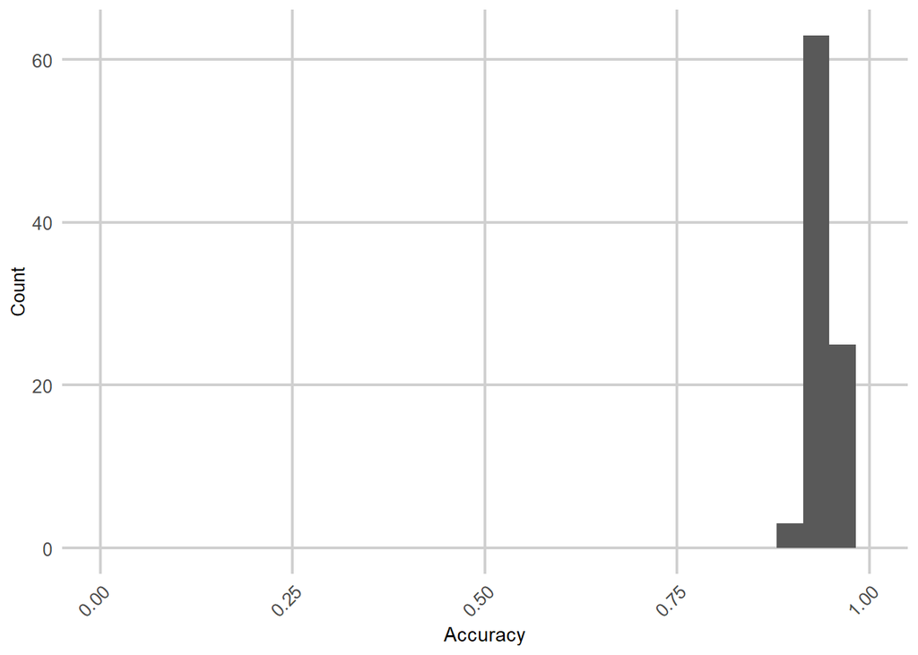

```r
ggplot(as.data.frame(Inundation_cvFit$resample), aes(Accuracy)) +
  geom_histogram() +
  scale_x_continuous(limits = c(0, 1)) +
  labs(x="Accuracy",
       y="Count")+
  plotTheme
```

### 3.3.4 Map Predictions

After predicting inundation probability for each cell, we append the prediction result to our original Calgary dataset and visualized the result in maps. The Predicted Inundation Probability in Quintile Breaks indicates the likelihood of flood for each cell. Darker color indicates a higher probability of being inundated, the Predicted Inundation Probability and Given Inundation Overlay map included an extra layer showing the cells labeled as inundated based on the given flood satellite image.

```r
allPredictions <-
  predict(Inundation_cvFit, Calgary_dat_new, type="prob")[,2]

Calgary_dat_new <-
  cbind(Calgary_dat_new,allPredictions) %>%
  mutate(allPredictions = round(allPredictions * 100))
```

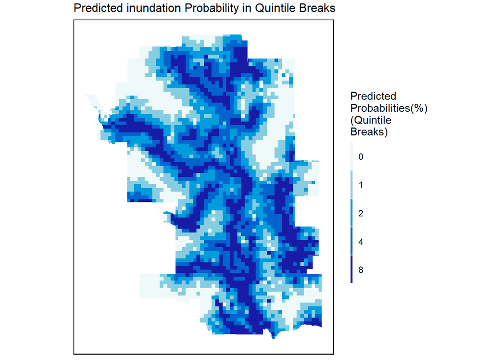

```r
ggplot() +
    geom_sf(data=Calgary_dat_new, aes(fill=factor(ntile(allPredictions,5))),
            colour=NA) +
    scale_fill_manual(values = c("#eff9f9","#86cde2","#009cdc","#0064cf","#181ba6"),
                      labels=as.character(quantile(Calgary_dat_new$allPredictions,
                                                 c(0.1,.2,.4,.6,.8),
                                                 na.rm=T)),
                      name="Predicted\nProbabilities(%)\n(Quintile\nBreaks)") +
  mapTheme +
  labs(title="Predicted inundation Probability in Quintile Breaks")
```

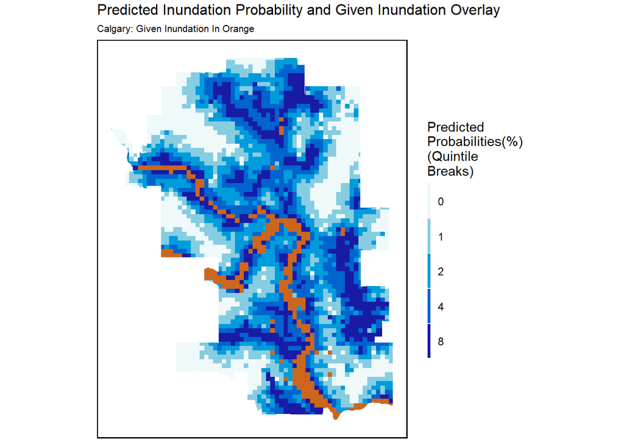

```r
ggplot() +
    geom_sf(data=Calgary_dat_new, aes(fill=factor(ntile(allPredictions,5))),
            colour=NA) +
    scale_fill_manual(values = c("#eff9f9","#86cde2","#009cdc","#0064cf","#181ba6"),
                      labels=as.character(quantile(Calgary_dat_new$allPredictions,
                                                 c(0.1,.2,.4,.6,.8),
                                                 na.rm=T)),
                      name="Predicted\nProbabilities(%)\n(Quintile\nBreaks)") +
  geom_sf(data=Calgary_dat_new %>%
               filter(Inundation_indicator == 1),
               fill="chocolate3",colour=NA) +
  mapTheme +
 labs(title="Predicted Inundation Probability and Given Inundation Overlay",
      subtitle="Calgary: Given Inundation In Orange")
```

### 3.3.5 Map Confusion Matrix

Here is a map showing the confusion matrix result spatially. As the map below shows, cells in green indicate areas that are predicted to be flooded and are inundation areas in reality. Cells in blue are areas predicted to be non-inundation areas and are also not inundated in reality; Cells in red are areas that are inundated areas but are predicted as non-inundation areas by the model. Such inaccuracy may induce safety risks when planning for flooding. And finally, the cells in orange indicate areas that are not inundated but are predicted as inundation areas. This type of inaccuracy may lead to extra expenditure when doing environmental planning. However, no model is perfect, and there are many approaches to improve the model, such as adjusting our assumption on what ratio is considered inundation.

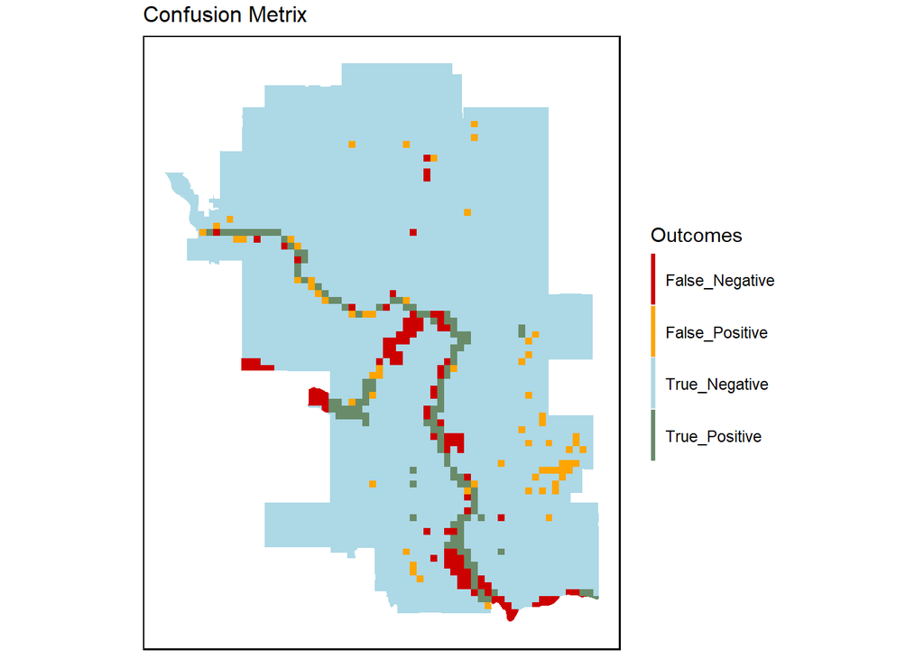

```r
Calgary_dat_new %>%
  mutate(cmResult=case_when(allPredictions < 25 & Inundation_indicator==0 ~ "True_Negative",
                              allPredictions >= 25 & Inundation_indicator==1 ~ "True_Positive",
                              allPredictions < 25 & Inundation_indicator==1 ~ "False_Negative",
                              allPredictions >= 25 & Inundation_indicator==0 ~ "False_Positive")) %>%
  ggplot()+
  geom_sf(aes(fill = cmResult), color = "transparent")+
  scale_fill_manual(values = c("red3","Orange","Light Blue","darkseagreen4"),
                    name="Outcomes")+
  labs(title="Confusion Metrix") +
  mapTheme
```

### 3.3.6 Plot Inundation area in Calgary

Here is a map showing predicted inundation area.

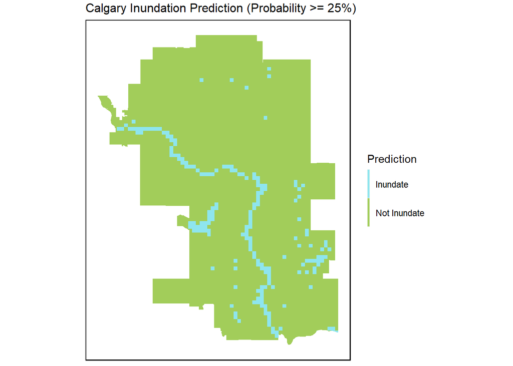

```r
# Based on our assumption, a cell will be considered as Inundated when the probability of Inundation exceed 25%.
Calgary_dat_new <-
  Calgary_dat_new %>%
  mutate(Will_Inundate = ifelse(allPredictions < 25,1,0))

ggplot() +
    geom_sf(data=Calgary_dat_new, aes(fill=factor(Will_Inundate)), colour=NA) +
    scale_fill_manual(values = c("cadetblue2","darkolivegreen3"),
                      labels=c("Inundate","Not Inundate"),
                      name="Prediction") +
  mapTheme+
  labs(title="Calgary Inundation Prediction (Probability >= 25%)")
```

# 4. Model Application on Edmonton

Our group used Edmonton as the comparable city because it shares similar population, size, and climate characteristics with Calgary, which could improve the validity of applying the trained model.

```r
#engineering data for Edmonton:
Edmonton_dat_new <- Edmonton_dat %>%
  mutate(Dis_Stream_mile = Dis_Strm/1609.34,
         Pct_water = Pct_Water) %>%
  dplyr::select(-Shape_Leng, -Shape_Area,-geometry,-Pct_Water,-Dis_Strm) # convert from meter to mile for better histogram visualization.
```

## 4.1 Visualize Edmonton dataset

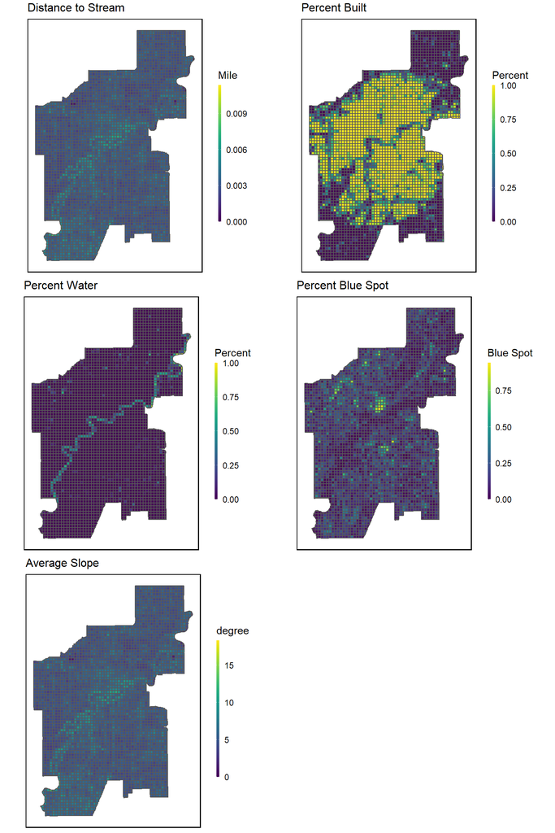

```r
Edmonton_Dis_stream_Plot <-
  ggplot() +
    geom_sf(data = Edmonton_dat_new, aes(fill=Dis_Stream_mile)) +
    scale_fill_viridis(name="Mile") + labs(title="Distance to Stream") +
    mapTheme

Edmonton_Pct_Built_Plot <-
  ggplot() +
    geom_sf(data=Edmonton_dat_new, aes(fill=Pct_Built)) +
    scale_fill_viridis(name="Percent") + labs(title="Percent Built") +
    mapTheme

Edmonton_Pct_water_Plot <-
  ggplot() +
    geom_sf(data=Edmonton_dat_new, aes(fill=Pct_water)) +
    scale_fill_viridis(name="Percent") + labs(title="Percent Water") +
    mapTheme

Edmonton_BS_Plot <-
  ggplot() +
    geom_sf(data=Edmonton_dat_new, aes(fill=Pct_BS)) +
    scale_fill_viridis(name="Blue Spot") + labs(title="Percent Blue Spot") +
    mapTheme

Edmonton_Ave_Slope_Plot <-
  ggplot() +
    geom_sf(data=Edmonton_dat_new, aes(fill=Ave_Slope)) +
    scale_fill_viridis(name="degree") + labs(title="Average Slope") +
    mapTheme

grid.arrange(Edmonton_Dis_stream_Plot,Edmonton_Pct_Built_Plot,Edmonton_Pct_water_Plot,Edmonton_BS_Plot,
             Edmonton_Ave_Slope_Plot, ncol=2)
```

## 4.2 Predict Inundation Probability

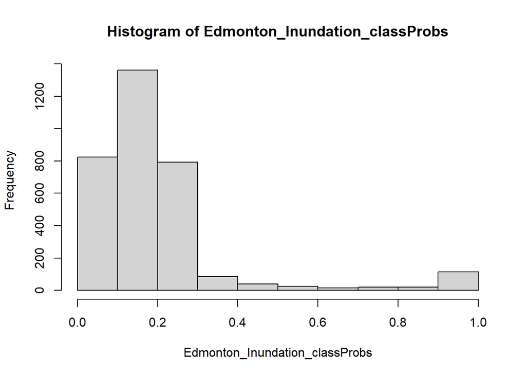

```r
Edmonton_Inundation_classProbs <- predict(InundationModel, Edmonton_dat_new, type="response")
hist(Edmonton_Inundation_classProbs)
```

```r
Edmonton_dat_new <-
  cbind(Edmonton_dat_new,Edmonton_Inundation_classProbs) %>%
  mutate(Edmonton_Inundation_classProbs = round(Edmonton_Inundation_classProbs * 100))
```

## 4.3 Visualize Result

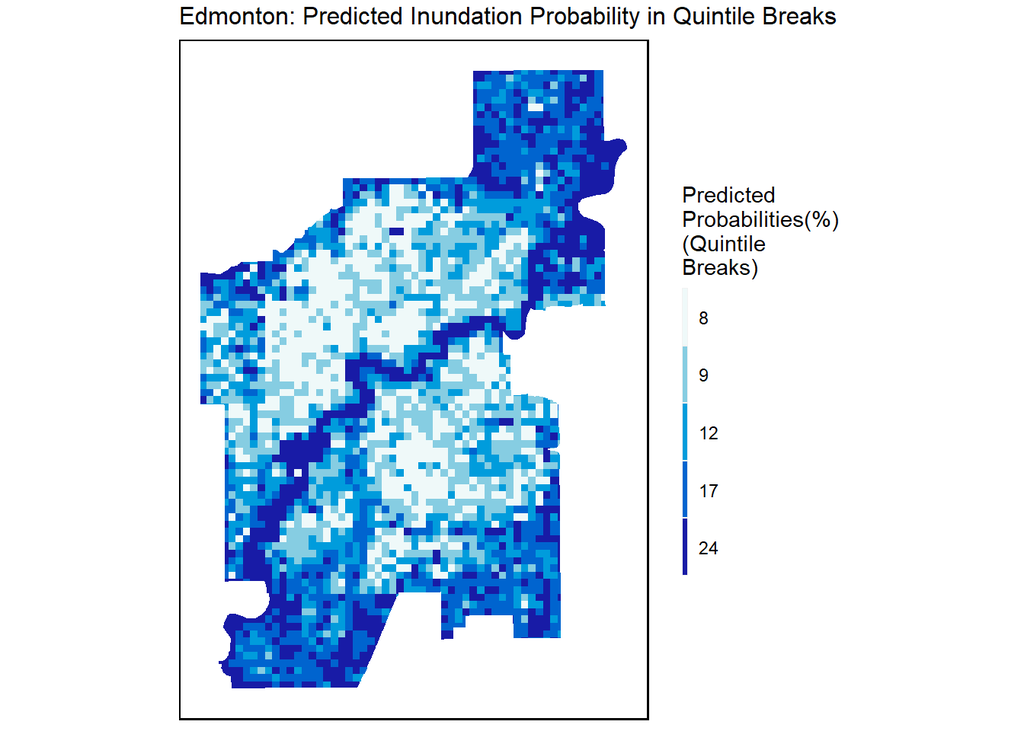

```r
ggplot() +
    geom_sf(data=Edmonton_dat_new, aes(fill=factor(ntile(Edmonton_Inundation_classProbs,5))),
            colour=NA) +
    scale_fill_manual(values = c("#eff9f9","#86cde2","#009cdc","#0064cf","#181ba6"),
                      labels=as.character(quantile(Edmonton_dat_new$Edmonton_Inundation_classProbs,
                                                 c(0.1,.2,.4,.6,.8),
                                                 na.rm=T)),
                      name="Predicted\nProbabilities(%)\n(Quintile\nBreaks)") +
  mapTheme +
  labs(title="Edmonton: Predicted Inundation Probability in Quintile Breaks")
```

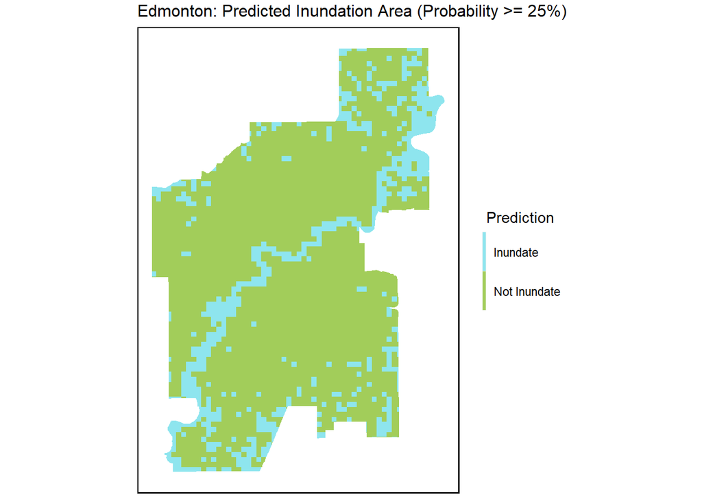

```r
# Based on our assumption, a cell will be considered as Inundated when the probability of Inundation exceed 25%.
Edmonton_dat_new <-
  Edmonton_dat_new %>%
  mutate(Will_Inundate = ifelse(Edmonton_Inundation_classProbs < 25,1,0))

ggplot() +
    geom_sf(data=Edmonton_dat_new, aes(fill=factor(Will_Inundate)), colour=NA) +
    scale_fill_manual(values = c("cadetblue2","darkolivegreen3"),
                      labels=c("Inundate","Not Inundate"),
                      name=" Prediction") +
  mapTheme +
  labs(title="Edmonton: Predicted Inundation Area (Probability >= 25%)")
```

# 5. Scenario

In the previous analysis, we categorized a cell as Inundate when the percent of inundation area exceeds or is equal to 25% of the total cell area. The confusion matrix result indicated some predictions turned out to be False Negative. To predict the worst scenario, we set this inundation threshold to > 0, which means if the cell has greater than 0% of land deemed as inundation in the satellite image, the entire cell will be considered inundated.

## 5.1 Define New Calgary Data

```r
Calgary_dat_new2 <- Calgary_dat %>%
  mutate(Inundation_indicator = as.integer(ifelse(Pct_Inun >0 ,1, 0)),  # change percent of inundation to a dummy indicator.
         Dis_Stream_mile = Dis_Stream/1609.34)  # convert from meter to mile for better histogram visualization.
```

## 5.2 Visualize New Data

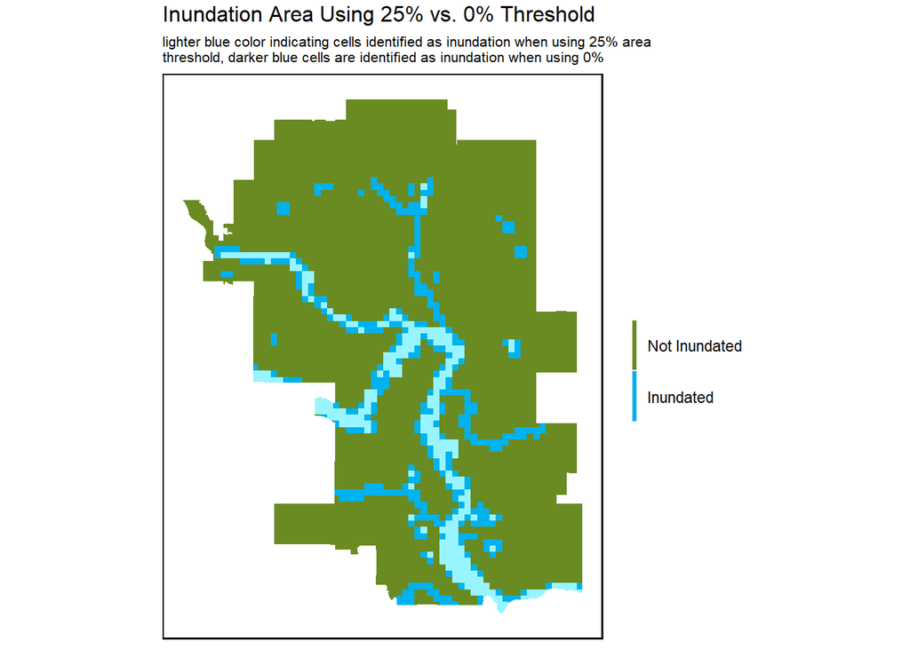

```r
ggplot() +
  geom_sf(data=Calgary_dat_new2, aes(fill=as.factor(Inundation_indicator)), color = "transparent") +
  scale_fill_manual(values = c("olivedrab4", "deepskyblue2"),
                    labels = c("Not Inundated","Inundated"),
                    name = "") +
  geom_sf(data=Calgary_dat_new %>%
               filter(Inundation_indicator == 1),
               fill="cadetblue1",colour=NA) +
  mapTheme +
  labs(title="Inundation Area Using 25% vs. 0% Threshold",
      subtitle="lighter blue color indicating cells identified as inundation when using 25% area
threshold, darker blue cells are identified as inundation when using 0%")
```